# Flight Data Analysis

## Preliminary Wrangling

> This dataset contains flight arrival and departure details for all commercial flights within the USA including cancellation and delay information. The dataset is from the most recent year the data was available which was 2008.

```python
# importing all required packages
import numpy as np
import pandas as pd
import matplotlib.pyplot as plt
import seaborn as sb

%matplotlib inline
```

> Load in dataset for exploration in this section:

```python
df=pd.read_csv('2008.csv.bz2', compression='bz2')
```

```python
#see number of non-nulls, and dataframe info:
df.info(null_counts=True)
print(df.shape)
df.sample(10)
```

```
<class 'pandas.core.frame.DataFrame'>
RangeIndex: 7009728 entries, 0 to 7009727
Data columns (total 29 columns):
Year                 7009728 non-null int64
Month                7009728 non-null int64
DayofMonth           7009728 non-null int64
DayOfWeek            7009728 non-null int64
DepTime              6873482 non-null float64
CRSDepTime           7009728 non-null int64
ArrTime              6858079 non-null float64
CRSArrTime           7009728 non-null int64
UniqueCarrier        7009728 non-null object
FlightNum            7009728 non-null int64
TailNum              6926363 non-null object
ActualElapsedTime    6855029 non-null float64
CRSElapsedTime       7008884 non-null float64
AirTime              6855029 non-null float64
ArrDelay             6855029 non-null float64
DepDelay             6873482 non-null float64
Origin               7009728 non-null object
Dest                 7009728 non-null object
Distance             7009728 non-null int64
TaxiIn               6858079 non-null float64
TaxiOut              6872670 non-null float64
Cancelled            7009728 non-null int64
CancellationCode     137434 non-null object
Diverted             7009728 non-null int64
CarrierDelay         1524735 non-null float64
WeatherDelay         1524735 non-null float64
NASDelay             1524735 non-null float64
SecurityDelay        1524735 non-null float64
LateAircraftDelay    1524735 non-null float64
dtypes: float64(14), int64(10), object(5)
memory usage: 1.5+ GB
(7009728, 29)
```

|  | Year | Month | DayofMonth | DayOfWeek | DepTime | CRSDepTime | ArrTime | CRSArrTime | UniqueCarrier | FlightNum | ... | TaxiIn | TaxiOut | Cancelled | CancellationCode | Diverted | CarrierDelay | WeatherDelay | NASDelay | SecurityDelay | LateAircraftDelay |
| --- | --- | --- | --- | --- | --- | --- | --- | --- | --- | --- | --- | --- | --- | --- | --- | --- | --- | --- | --- | --- | --- |
| 6376869 | 2008 | 11 | 24 | 1 | 2011.0 | 2015 | 2201.0 | 2210 | AA | 1212 | ... | 6.0 | 17.0 | 0 | NaN | 0 | NaN | NaN | NaN | NaN | NaN |
| 2406766 | 2008 | 5 | 8 | 4 | 1126.0 | 1125 | 1656.0 | 1710 | WN | 3059 | ... | 6.0 | 6.0 | 0 | NaN | 0 | NaN | NaN | NaN | NaN | NaN |
| 6835428 | 2008 | 12 | 26 | 5 | 1116.0 | 910 | 1331.0 | 1100 | MQ | 4033 | ... | 6.0 | 45.0 | 0 | NaN | 0 | 0.0 | 126.0 | 25.0 | 0.0 | 0.0 |
| 910883 | 2008 | 2 | 5 | 2 | 1418.0 | 1400 | 1547.0 | 1527 | EV | 4208 | ... | 11.0 | 8.0 | 0 | NaN | 0 | 0.0 | 0.0 | 2.0 | 0.0 | 18.0 |
| 1986592 | 2008 | 4 | 2 | 3 | 1756.0 | 1745 | 2042.0 | 2035 | OO | 3926 | ... | 4.0 | 12.0 | 0 | NaN | 0 | NaN | NaN | NaN | NaN | NaN |
| 1143403 | 2008 | 2 | 18 | 1 | 1122.0 | 1115 | 1329.0 | 1337 | CO | 478 | ... | 7.0 | 14.0 | 0 | NaN | 0 | NaN | NaN | NaN | NaN | NaN |
| 2643229 | 2008 | 5 | 1 | 4 | 849.0 | 853 | 1107.0 | 1110 | UA | 1572 | ... | 6.0 | 14.0 | 0 | NaN | 0 | NaN | NaN | NaN | NaN | NaN |
| 570064 | 2008 | 1 | 23 | 3 | 831.0 | 715 | 926.0 | 807 | CO | 1841 | ... | 6.0 | 20.0 | 0 | NaN | 0 | 76.0 | 0.0 | 3.0 | 0.0 | 0.0 |
| 2634048 | 2008 | 5 | 17 | 6 | 919.0 | 917 | 1745.0 | 1717 | UA | 966 | ... | 32.0 | 13.0 | 0 | NaN | 0 | 0.0 | 0.0 | 28.0 | 0.0 | 0.0 |
| 3052973 | 2008 | 6 | 19 | 4 | 1301.0 | 1300 | 1510.0 | 1505 | WN | 3494 | ... | 5.0 | 7.0 | 0 | NaN | 0 | NaN | NaN | NaN | NaN | NaN |

10 rows × 29 columns

```python
#Cannot see all the data within the table so to temporaly display all the 29 columns:
with pd.option_context('display.max_columns', 29):
    display(df.head(10))
```

|  | Year | Month | DayofMonth | DayOfWeek | DepTime | CRSDepTime | ArrTime | CRSArrTime | UniqueCarrier | FlightNum | TailNum | ActualElapsedTime | CRSElapsedTime | AirTime | ArrDelay | DepDelay | Origin | Dest | Distance | TaxiIn | TaxiOut | Cancelled | CancellationCode | Diverted | CarrierDelay | WeatherDelay | NASDelay | SecurityDelay | LateAircraftDelay |
| --- | --- | --- | --- | --- | --- | --- | --- | --- | --- | --- | --- | --- | --- | --- | --- | --- | --- | --- | --- | --- | --- | --- | --- | --- | --- | --- | --- | --- | --- |
| 0 | 2008 | 1 | 3 | 4 | 2003.0 | 1955 | 2211.0 | 2225 | WN | 335 | N712SW | 128.0 | 150.0 | 116.0 | -14.0 | 8.0 | IAD | TPA | 810 | 4.0 | 8.0 | 0 | NaN | 0 | NaN | NaN | NaN | NaN | NaN |
| 1 | 2008 | 1 | 3 | 4 | 754.0 | 735 | 1002.0 | 1000 | WN | 3231 | N772SW | 128.0 | 145.0 | 113.0 | 2.0 | 19.0 | IAD | TPA | 810 | 5.0 | 10.0 | 0 | NaN | 0 | NaN | NaN | NaN | NaN | NaN |
| 2 | 2008 | 1 | 3 | 4 | 628.0 | 620 | 804.0 | 750 | WN | 448 | N428WN | 96.0 | 90.0 | 76.0 | 14.0 | 8.0 | IND | BWI | 515 | 3.0 | 17.0 | 0 | NaN | 0 | NaN | NaN | NaN | NaN | NaN |
| 3 | 2008 | 1 | 3 | 4 | 926.0 | 930 | 1054.0 | 1100 | WN | 1746 | N612SW | 88.0 | 90.0 | 78.0 | -6.0 | -4.0 | IND | BWI | 515 | 3.0 | 7.0 | 0 | NaN | 0 | NaN | NaN | NaN | NaN | NaN |
| 4 | 2008 | 1 | 3 | 4 | 1829.0 | 1755 | 1959.0 | 1925 | WN | 3920 | N464WN | 90.0 | 90.0 | 77.0 | 34.0 | 34.0 | IND | BWI | 515 | 3.0 | 10.0 | 0 | NaN | 0 | 2.0 | 0.0 | 0.0 | 0.0 | 32.0 |
| 5 | 2008 | 1 | 3 | 4 | 1940.0 | 1915 | 2121.0 | 2110 | WN | 378 | N726SW | 101.0 | 115.0 | 87.0 | 11.0 | 25.0 | IND | JAX | 688 | 4.0 | 10.0 | 0 | NaN | 0 | NaN | NaN | NaN | NaN | NaN |
| 6 | 2008 | 1 | 3 | 4 | 1937.0 | 1830 | 2037.0 | 1940 | WN | 509 | N763SW | 240.0 | 250.0 | 230.0 | 57.0 | 67.0 | IND | LAS | 1591 | 3.0 | 7.0 | 0 | NaN | 0 | 10.0 | 0.0 | 0.0 | 0.0 | 47.0 |
| 7 | 2008 | 1 | 3 | 4 | 1039.0 | 1040 | 1132.0 | 1150 | WN | 535 | N428WN | 233.0 | 250.0 | 219.0 | -18.0 | -1.0 | IND | LAS | 1591 | 7.0 | 7.0 | 0 | NaN | 0 | NaN | NaN | NaN | NaN | NaN |
| 8 | 2008 | 1 | 3 | 4 | 617.0 | 615 | 652.0 | 650 | WN | 11 | N689SW | 95.0 | 95.0 | 70.0 | 2.0 | 2.0 | IND | MCI | 451 | 6.0 | 19.0 | 0 | NaN | 0 | NaN | NaN | NaN | NaN | NaN |
| 9 | 2008 | 1 | 3 | 4 | 1620.0 | 1620 | 1639.0 | 1655 | WN | 810 | N648SW | 79.0 | 95.0 | 70.0 | -16.0 | 0.0 | IND | MCI | 451 | 3.0 | 6.0 | 0 | NaN | 0 | NaN | NaN | NaN | NaN | NaN |

```python
#summarizing missing values:
df.isnull().values.any()
df.isnull().sum()
```

```
Year                       0
Month                      0
DayofMonth                 0
DayOfWeek                  0
DepTime               136246
CRSDepTime                 0
ArrTime               151649
CRSArrTime                 0
UniqueCarrier              0
FlightNum                  0
TailNum                83365
ActualElapsedTime     154699
CRSElapsedTime           844
AirTime               154699
ArrDelay              154699
DepDelay              136246
Origin                     0
Dest                       0
Distance                   0
TaxiIn                151649
TaxiOut               137058
Cancelled                  0
CancellationCode     6872294
Diverted                   0
CarrierDelay         5484993
WeatherDelay         5484993
NASDelay             5484993
SecurityDelay        5484993
LateAircraftDelay    5484993
dtype: int64
```

```python
df[df.DepDelay.isnull()].tail(10)
```

|  | Year | Month | DayofMonth | DayOfWeek | DepTime | CRSDepTime | ArrTime | CRSArrTime | UniqueCarrier | FlightNum | ... | TaxiIn | TaxiOut | Cancelled | CancellationCode | Diverted | CarrierDelay | WeatherDelay | NASDelay | SecurityDelay | LateAircraftDelay |
| --- | --- | --- | --- | --- | --- | --- | --- | --- | --- | --- | --- | --- | --- | --- | --- | --- | --- | --- | --- | --- | --- |
| 7008869 | 2008 | 12 | 12 | 5 | NaN | 1048 | NaN | 1205 | DL | 1659 | ... | NaN | NaN | 1 | A | 0 | NaN | NaN | NaN | NaN | NaN |
| 7008900 | 2008 | 12 | 12 | 5 | NaN | 1455 | NaN | 1602 | DL | 1694 | ... | NaN | NaN | 1 | A | 0 | NaN | NaN | NaN | NaN | NaN |
| 7008940 | 2008 | 12 | 12 | 5 | NaN | 830 | NaN | 1048 | DL | 1732 | ... | NaN | NaN | 1 | A | 0 | NaN | NaN | NaN | NaN | NaN |
| 7009396 | 2008 | 12 | 13 | 6 | NaN | 905 | NaN | 1118 | DL | 1133 | ... | NaN | NaN | 1 | A | 0 | NaN | NaN | NaN | NaN | NaN |
| 7009397 | 2008 | 12 | 13 | 6 | NaN | 1330 | NaN | 1540 | DL | 1138 | ... | NaN | NaN | 1 | A | 0 | NaN | NaN | NaN | NaN | NaN |
| 7009455 | 2008 | 12 | 13 | 6 | NaN | 600 | NaN | 815 | DL | 1211 | ... | NaN | NaN | 1 | A | 0 | NaN | NaN | NaN | NaN | NaN |
| 7009464 | 2008 | 12 | 13 | 6 | NaN | 1930 | NaN | 2129 | DL | 1218 | ... | NaN | NaN | 1 | A | 0 | NaN | NaN | NaN | NaN | NaN |
| 7009564 | 2008 | 12 | 13 | 6 | NaN | 700 | NaN | 1035 | DL | 1421 | ... | NaN | NaN | 1 | A | 0 | NaN | NaN | NaN | NaN | NaN |
| 7009565 | 2008 | 12 | 13 | 6 | NaN | 1115 | NaN | 1432 | DL | 1422 | ... | NaN | NaN | 1 | A | 0 | NaN | NaN | NaN | NaN | NaN |
| 7009648 | 2008 | 12 | 13 | 6 | NaN | 1020 | NaN | 1126 | DL | 1532 | ... | NaN | NaN | 1 | A | 0 | NaN | NaN | NaN | NaN | NaN |

10 rows × 29 columns

```python
df[df.DepDelay.isnull()].tail(10)
```

```python
#going to make a copy of the data to work with (df_clean):

df_clean = df.copy()
```

```python
# adding `Delayed` as a new column if the flight is delayed based on `DepDelay/departure delay` as 1 (Yes) or 0 (No)
df_clean['Delayed'] = df['DepDelay'].apply(lambda x : 1 if x > 0 else 0)
df_clean[[ 'DepDelay','Delayed']].tail()
```

|  | DepDelay | Delayed |
| --- | --- | --- |
| 7009723 | 3.0 | 1 |
| 7009724 | -1.0 | 0 |
| 7009725 | -5.0 | 0 |
| 7009726 | 11.0 | 1 |
| 7009727 | 7.0 | 1 |

```python
# converting all NaN's to 0's in columns CarrierDelay, WeatherDelay, NASDelay, SecurityDelay, LateAircraftDelay to get rid of all the Nulls in features of interest
col_list = ['CarrierDelay', 'WeatherDelay', 'NASDelay', 'SecurityDelay', 'LateAircraftDelay', 'CancellationCode']
for col in col_list:
    df_clean[col].fillna(0, inplace=True)

print(df_clean[col_list].isnull().sum())
```

```
CarrierDelay         0
WeatherDelay         0
NASDelay             0
SecurityDelay        0
LateAircraftDelay    0
CancellationCode     0
dtype: int64
```

```python
#displaying all 30 columns
with pd.option_context('display.max_columns', 30):
    display(df_clean.tail())
```

|  | Year | Month | DayofMonth | DayOfWeek | DepTime | CRSDepTime | ArrTime | CRSArrTime | UniqueCarrier | FlightNum | TailNum | ActualElapsedTime | CRSElapsedTime | AirTime | ArrDelay | DepDelay | Origin | Dest | Distance | TaxiIn | TaxiOut | Cancelled | CancellationCode | Diverted | CarrierDelay | WeatherDelay | NASDelay | SecurityDelay | LateAircraftDelay | … |
| --- | --- | --- | --- | --- | --- | --- | --- | --- | --- | --- | --- | --- | --- | --- | --- | --- | --- | --- | --- | --- | --- | --- | --- | --- | --- | --- | --- | --- | --- | --- |
| 7009723 | 2008 | 12 | 13 | 6 | 1002.0 | 959 | 1204.0 | 1150 | DL | 1636 | N646DL | 122.0 | 111.0 | 71.0 | 14.0 | 3.0 | ATL | IAD | 533 | 6.0 | 45.0 | 0 | 0 | 0 | 0.0 | 0.0 | 0.0 | 0.0 | 0.0 | … |
| 7009724 | 2008 | 12 | 13 | 6 | 834.0 | 835 | 1021.0 | 1023 | DL | 1637 | N908DL | 167.0 | 168.0 | 139.0 | -2.0 | -1.0 | ATL | SAT | 874 | 5.0 | 23.0 | 0 | 0 | 0 | 0.0 | 0.0 | 0.0 | 0.0 | 0.0 | … |
| 7009725 | 2008 | 12 | 13 | 6 | 655.0 | 700 | 856.0 | 856 | DL | 1638 | N671DN | 121.0 | 116.0 | 85.0 | 0.0 | -5.0 | PBI | ATL | 545 | 24.0 | 12.0 | 0 | 0 | 0 | 0.0 | 0.0 | 0.0 | 0.0 | 0.0 | … |
| 7009726 | 2008 | 12 | 13 | 6 | 1251.0 | 1240 | 1446.0 | 1437 | DL | 1639 | N646DL | 115.0 | 117.0 | 89.0 | 9.0 | 11.0 | IAD | ATL | 533 | 13.0 | 13.0 | 0 | 0 | 0 | 0.0 | 0.0 | 0.0 | 0.0 | 0.0 | … |
| 7009727 | 2008 | 12 | 13 | 6 | 1110.0 | 1103 | 1413.0 | 1418 | DL | 1641 | N908DL | 123.0 | 135.0 | 104.0 | -5.0 | 7.0 | SAT | ATL | 874 | 8.0 | 11.0 | 0 | 0 | 0 | 0.0 | 0.0 | 0.0 | 0.0 | 0.0 | … |

```python
df_clean.info(null_counts=True)
```

```
<class 'pandas.core.frame.DataFrame'>
RangeIndex: 7009728 entries, 0 to 7009727
Data columns (total 30 columns):
Year                 7009728 non-null int64
Month                7009728 non-null int64
DayofMonth           7009728 non-null int64
DayOfWeek            7009728 non-null int64
DepTime              6873482 non-null float64
CRSDepTime           7009728 non-null int64
ArrTime              6858079 non-null float64
CRSArrTime           7009728 non-null int64
UniqueCarrier        7009728 non-null object
FlightNum            7009728 non-null int64
TailNum              6926363 non-null object
ActualElapsedTime    6855029 non-null float64
CRSElapsedTime       7008884 non-null float64
AirTime              6855029 non-null float64
ArrDelay             6855029 non-null float64
DepDelay             6873482 non-null float64
Origin               7009728 non-null object
Dest                 7009728 non-null object
Distance             7009728 non-null int64
TaxiIn               6858079 non-null float64
TaxiOut              6872670 non-null float64
Cancelled            7009728 non-null int64
CancellationCode     7009728 non-null object
Diverted             7009728 non-null int64
CarrierDelay         7009728 non-null float64
WeatherDelay         7009728 non-null float64
NASDelay             7009728 non-null float64
SecurityDelay        7009728 non-null float64
LateAircraftDelay    7009728 non-null float64
Delayed              7009728 non-null int64
dtypes: float64(14), int64(11), object(5)
memory usage: 1.6+ GB
```

> notes to carry forward and think about: A flight delay is when an airline flight takes off and/or lands later than its scheduled time. The Federal Aviation Administration (FAA) considers a flight to be delayed when it is 15 minutes later than its scheduled time. A cancellation occurs when the airline does not operate the flight at all for a certain reason. source: https://www.bts.gov/topics/airlines-and-airports/airline-time-performance-and-causes-flight-delays

```python
df_clean[df_clean['ArrDelay'] >= 15].head()
```

|  | Year | Month | DayofMonth | DayOfWeek | DepTime | CRSDepTime | ArrTime | CRSArrTime | UniqueCarrier | FlightNum | ... | Cancelled | CancellationCode | Diverted | CarrierDelay | WeatherDelay | NASDelay | SecurityDelay | LateAircraftDelay | Delayed | CRSDepHour |
| --- | --- | --- | --- | --- | --- | --- | --- | --- | --- | --- | --- | --- | --- | --- | --- | --- | --- | --- | --- | --- | --- |
| 4 | 2008 | 1 | 3 | 4 | 1829.0 | 1755 | 1959.0 | 1925 | WN | 3920 | ... | 0 | 0 | 0 | 2.0 | 0.0 | 0.0 | 0.0 | 32.0 | 1 | (1700, 1800] |
| 6 | 2008 | 1 | 3 | 4 | 1937.0 | 1830 | 2037.0 | 1940 | WN | 509 | ... | 0 | 0 | 0 | 10.0 | 0.0 | 0.0 | 0.0 | 47.0 | 1 | (1800, 1900] |
| 11 | 2008 | 1 | 3 | 4 | 1644.0 | 1510 | 1845.0 | 1725 | WN | 1333 | ... | 0 | 0 | 0 | 8.0 | 0.0 | 0.0 | 0.0 | 72.0 | 1 | (1500, 1600] |
| 16 | 2008 | 1 | 3 | 4 | 1452.0 | 1425 | 1640.0 | 1625 | WN | 675 | ... | 0 | 0 | 0 | 3.0 | 0.0 | 0.0 | 0.0 | 12.0 | 1 | (1400, 1500] |
| 18 | 2008 | 1 | 3 | 4 | 1323.0 | 1255 | 1526.0 | 1510 | WN | 4 | ... | 0 | 0 | 0 | 0.0 | 0.0 | 0.0 | 0.0 | 16.0 | 1 | (1200, 1300] |

5 rows × 31 columns

```python
df_clean[df_clean['ArrDelay'] <= 15].head()
```

|  | Year | Month | DayofMonth | DayOfWeek | DepTime | CRSDepTime | ArrTime | CRSArrTime | UniqueCarrier | FlightNum | ... | Cancelled | CancellationCode | Diverted | CarrierDelay | WeatherDelay | NASDelay | SecurityDelay | LateAircraftDelay | Delayed | CRSDepHour |
| --- | --- | --- | --- | --- | --- | --- | --- | --- | --- | --- | --- | --- | --- | --- | --- | --- | --- | --- | --- | --- | --- |
| 0 | 2008 | 1 | 3 | 4 | 2003.0 | 1955 | 2211.0 | 2225 | WN | 335 | ... | 0 | 0 | 0 | 0.0 | 0.0 | 0.0 | 0.0 | 0.0 | 0 | (1900, 2000] |
| 1 | 2008 | 1 | 3 | 4 | 754.0 | 735 | 1002.0 | 1000 | WN | 3231 | ... | 0 | 0 | 0 | 0.0 | 0.0 | 0.0 | 0.0 | 0.0 | 1 | (700, 800] |
| 2 | 2008 | 1 | 3 | 4 | 628.0 | 620 | 804.0 | 750 | WN | 448 | ... | 0 | 0 | 0 | 0.0 | 0.0 | 0.0 | 0.0 | 0.0 | 0 | (600, 700] |
| 3 | 2008 | 1 | 3 | 4 | 926.0 | 930 | 1054.0 | 1100 | WN | 1746 | ... | 0 | 0 | 0 | 0.0 | 0.0 | 0.0 | 0.0 | 0.0 | 0 | (900, 1000] |
| 5 | 2008 | 1 | 3 | 4 | 1940.0 | 1915 | 2121.0 | 2110 | WN | 378 | ... | 0 | 0 | 0 | 0.0 | 0.0 | 0.0 | 0.0 | 0.0 | 1 | (1900, 2000] |

5 rows × 31 columns

> The following observation can be seen from a quick analysis of the data above:
> - When ArrDelay or DepDelay is bigger or equal to 15 minutes we see data about what caused the delay in the columns of CarrierDelay, WeatherDelay, NASDelay and LateAircraftDelay. The sum of these columns is equal to the DepDelay or ArrDelay.
> - When a flight is Cancelled or diverted, we see no data related to cause of the delay.

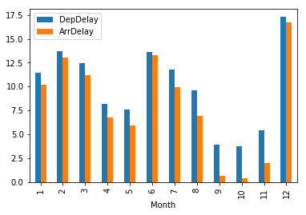

```python
# to quickly overview of the best/worst month in terms of flight departure delays:
df_clean.groupby('Month').agg({'DepDelay':'mean', 'ArrDelay':'mean'}).plot.bar()
plt.show()
```

> shows December as the worst month to fly with over17 minutes of delay time, and sept/oct as the best months.

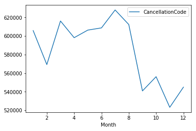

```python
#cancellation by month
df_clean[['Month','CancellationCode']].groupby(['Month']).count().plot()
plt.show()
```

```python
#worst time to travel:
df_clean['CRSDepHour'] = pd.cut(df.CRSDepTime, list(range(0, 2500, 100)))
```

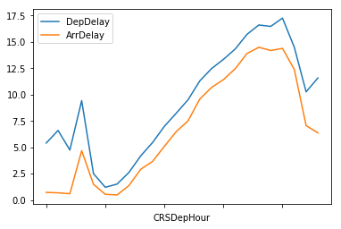

```python
df_clean.groupby('CRSDepHour').agg({'DepDelay':'mean', 'ArrDelay':'mean'}).plot()
plt.show()
```

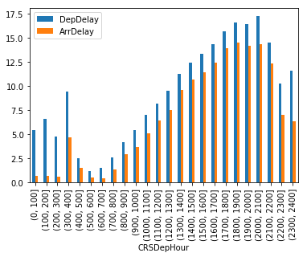

```python
# best/worst dep/arr hour:

df_clean.groupby('CRSDepHour').agg({'DepDelay':'mean', 'ArrDelay':'mean'}).plot.bar()
plt.show()
```

### What is the structure of your dataset?

> We have a large Airline flight performance dataset that contains 7,009,728 flights with 29 features/variables. The dataset is for the year 2008.

Some issues were found and resolved to make the dataset better for analyzing and visualizing, such as inconsistent null value and some missing usefull columns.

### What is/are the main feature(s) of interest in your dataset?

> I'm mostly interested in figuring out the following:
- what causes the delays?
- when does the most delays happen? (day, month, time)
- what types of delays happens the most?
- what features are best for predicting whether there will be a delay for the flight or not.
- what features are best for predicting whether the flight will be canceled or not.

### What features in the dataset do you think will help support your investigation into your feature(s) of interest?

> I think features such as Origin, Weather or any other delay reasons, Destination, Diverted flights and Carrier might have major effect in delaying or canceling a flight.

## Univariate Exploration

> In this section, investigate distributions of individual variables. If you see unusual points or outliers, take a deeper look to clean things up and prepare yourself to look at relationships between variables.

```python
#lets start by finding the mean of Delayed
df_clean.Delayed.mean()
```

```
0.3853179467163348
```

```python
#oh, I forgot to use the information I got in regards to what is considered as delayed (>15 min), lets see if the data will also say the same thing:

df_clean[df_clean['DepDelay'] > 0].DepDelay.describe()
```

```
count    2.700974e+06
mean     3.170540e+01
std      4.877991e+01
min      1.000000e+00
25%      5.000000e+00
50%      1.400000e+01
75%      3.800000e+01
max      2.467000e+03
Name: DepDelay, dtype: float64
```

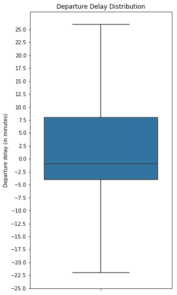

```python
#but lets figure out what our data tells us about the delay time, we are not showing the outliers here:
plt.figure(figsize=[5, 10])
sb.boxplot(y="DepDelay", data=df_clean,  showfliers=False)
plt.ylabel('Departure delay (in minutes)')
plt.yticks(np.arange(-25, 25+2.5, 2.5))
plt.title('Departure Delay Distribution')
plt.show();
```

We can see from above data that most departure delays happen from -5 to 7.5 minutes

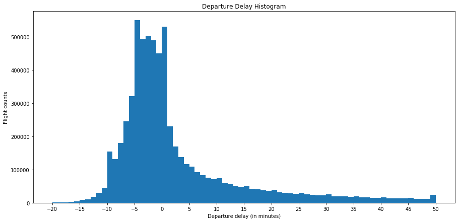

```python
# let's see the distribution of delayed data

bins = np.arange(-20, 50+1, 1)

plt.figure(figsize=[15, 7])
plt.hist(data = df_clean, x = 'DepDelay', bins = bins);
plt.xlabel('Departure delay (in minutes)')
plt.ylabel('Flight counts')
plt.xticks(np.arange(-20, 50+5, 5))
plt.title('Departure Delay Histogram')
plt.show();
```

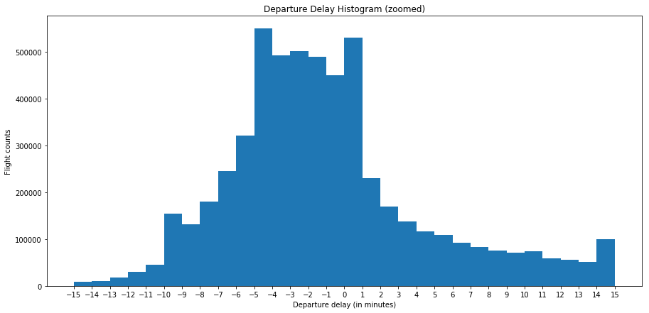

```python
# zooming into the cut off points:


bins = np.arange(-15, 15+1, 1)
plt.figure(figsize=[15, 7])
plt.hist(data = df_clean, x = 'DepDelay', bins = bins);
plt.xlabel('Departure delay (in minutes)')
plt.ylabel('Flight counts')
plt.xticks(np.arange(-15, 15+1, 1))
plt.title('Departure Delay Histogram (zoomed)')
plt.show()
```

In the above hist we can clearly see that the DepDelay is roughly clustered around -10 to 15 minutes.

I will incorporate delayed true only if departure delay is greater than 15 minutes.

```python
df_clean['Delayed'] = df['DepDelay'].apply(lambda x : 1 if x >= 15 else 0)
df_clean[['Delayed', 'DepDelay']].head()
```

|  | Delayed | DepDelay |
| --- | --- | --- |
| 0 | 0 | 8.0 |
| 1 | 1 | 19.0 |
| 2 | 0 | 8.0 |
| 3 | 0 | -4.0 |
| 4 | 1 | 34.0 |

```python
df_clean.Delayed.mean()
```

```
0.18941505290932828
```

Based on the decision we have made above, the delay rate is @19%.

Next, I will look at different type of delays:CarrierDelay, WeatherDelay, NASDelay, SecurityDelay, and LateAircraftDelay.

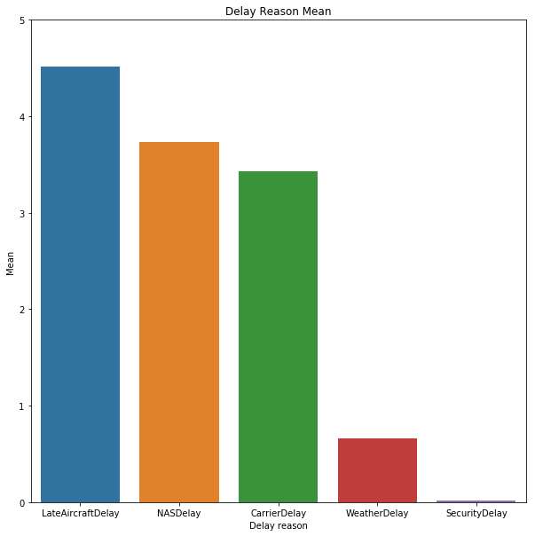

```python
col_list = ['CarrierDelay', 'WeatherDelay', 'NASDelay', 'SecurityDelay', 'LateAircraftDelay']
y = df_clean[col_list].mean().sort_values(ascending=False)
x = y.index

plt.figure(figsize=[10, 10])
sb.barplot(y = y, x = x)
plt.ylabel('Mean')
plt.xlabel('Delay reason')
plt.title('Delay Reason Mean')
plt.yticks(np.arange(0, df_clean[col_list].mean().max()+1, 1))
plt.show()
```

I will check the cancelled flights rate next

```python
#lets start by getting the mean of cancelled flights
df_clean.Cancelled.mean()
```

```
0.019606181580797428
```

This shows cancelled flights rate as around 2% of the time. We can check different type of cancellation based on the column CancellationCode:

```python
df_clean.CancellationCode.unique()
```

```
array([0, 'A', 'C', 'B', 'D'], dtype=object)
```

Cancellation code meaning: (A = carrier, B = weather, C = NAS, D = security, 0= Not Cancelled)

```python
df_clean.groupby(['CancellationCode']).size()
```

```
CancellationCode
0    6872294
A      54330
B      54904
C      28188
D         12
dtype: int64
```

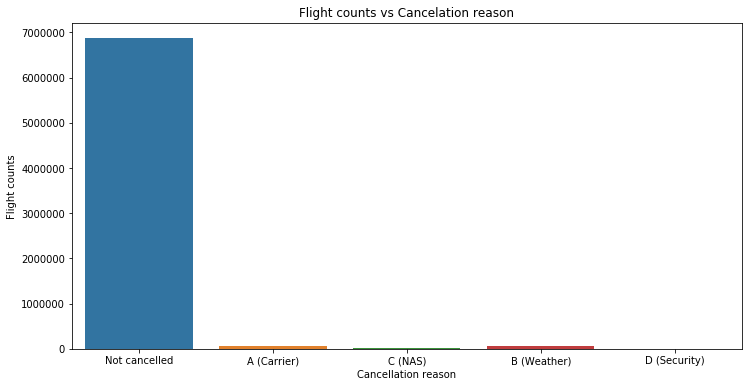

```python
ticks = ['Not cancelled','A (Carrier)', 'C (NAS)', 'B (Weather)', 'D (Security)']

plt.figure(figsize=[12, 6])
fig=sb.countplot(data= df_clean, x = 'CancellationCode')
fig.set_xticklabels(ticks)
plt.ylabel('Flight counts')
plt.xlabel('Cancellation reason')
plt.title('Flight counts vs Cancelation reason')
plt.show()
```

It seems that most flights were not cancelled, if we leave it in the plot we cannot really see the difference among the rest of the cancellation reasons, for better visualization, I am going to take out the not cancelled

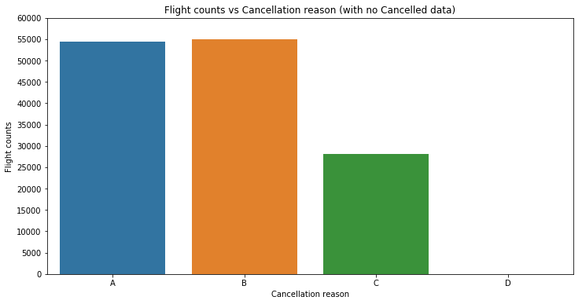

```python
#plot with no cancellation data for better visualization

ticks = ['A', 'B', 'C', 'D'];
plt.figure(figsize=[12, 6])
sb.countplot(data = df_clean, x = 'CancellationCode', order=ticks)
plt.yticks(np.arange(0, 60000+5000, 5000))
plt.ylabel('Flight counts')
plt.xlabel('Cancellation reason')
plt.title('Flight counts vs Cancellation reason (with no Cancelled data)')
plt.show()
```

okay, do we want to see the percentages for a better understanding of the difference between A, and B?

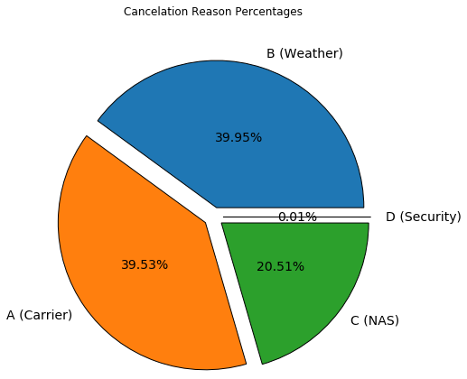

```python
y = np.array(list(df_clean[df_clean['CancellationCode'] != 'None']['CancellationCode'].value_counts())[1:5])
labels = ['B (Weather)', 'A (Carrier)', 'C (NAS)', 'D (Security)']
explode = (0.1, 0.1, 0.1, 0.1)
wedgeprops={"edgecolor":"k", 'antialiased': True}

plt.pie(y, labels=labels, autopct='%1.2f%%', pctdistance=0.5,
        labeldistance=1.1, radius=1.5, textprops={'fontsize': 14},
        explode=explode, wedgeprops=wedgeprops)
plt.title('Cancelation Reason Percentages')
plt.ylim([0,2])
plt.show()
```

uhha! now I can clearly see the order is weather, carrier, NAS, and security for cancellation. Much better! Almost 80% of flights are cancelled because of weather or carrier. The remaining 20% is because of NAS. Security factor is very small.

### Discuss the distribution(s) of your variable(s) of interest. Were there any unusual points? Did you need to perform any transformations?

> The Delayed variable was the variable I had to dig further in, at first I read about norm of delayed time, then saw that in the data that If I do not include the threshold the % of the delayed flights will be really high and seemed unusuall. I also observed that delayed reasons are only shown when DepDelay or DepArr is greater or equal to 15. Based on all these factors, I have decided to incorporate both my findings from the data, and the norm of `delayed` in concept and put the threshold at anyflight that is delayed more than 15 minutes.

> The other variable I worked with was the cancellation. Around 2% of the flights are cancelled and this did not come accross as odd and therefore I did not perform any transformation for this data like the way I did for the Delayed data.

### Of the features you investigated, were there any unusual distributions? Did you perform any operations on the data to tidy, adjust, or change the form of the data? If so, why did you do this?

> I had a debate whether I should change the time from minute to regular datetime format, but after going through the analysis I realized that is not necessary. However, I had that listed as things to be changed at first.

> I added the column Delayed in which I have set the threshold to be >=15 in minutes and made the column to 0 for no delay and 1 if it was delayed.

> I have excluded the outliers in the DepDelay column for better and more accurate visualization

> Also I replaced the Nan's with a 0 in my features of interest.

## Bivariate Exploration

> In this section, investigate relationships between pairs of variables in your data. Make sure the variables that you cover here have been introduced in some fashion in the previous section (univariate exploration).

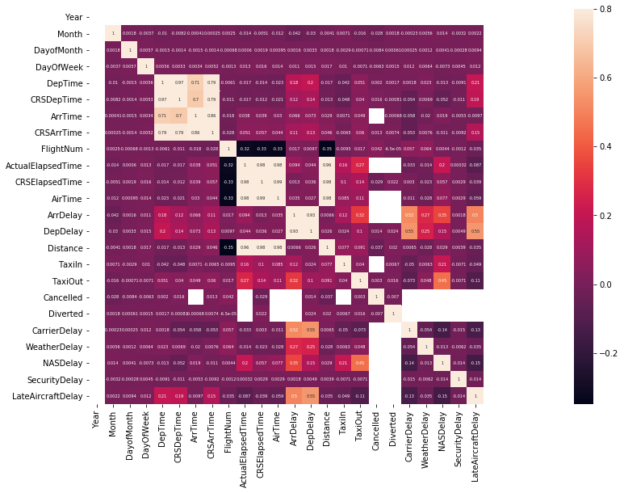

```python
#trying to see at a glance if I can spot relationships between variables:
corrmat = df.corr()
f, ax = plt.subplots(figsize=(40, 9))
sb.heatmap(corrmat, vmax=.8,annot=True, annot_kws={'size': 5}, square=True);
plt.show()
```

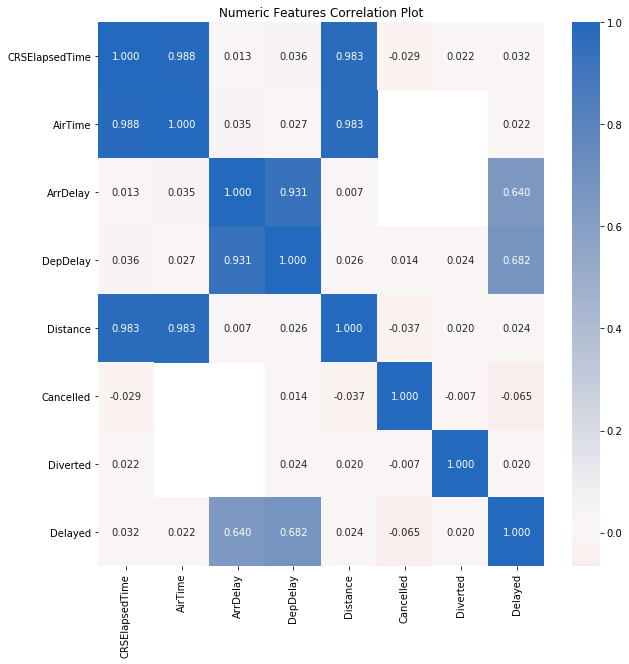

```python
#correlation plot for numeric features:

numeric_vars = ['CRSElapsedTime', 'AirTime', 'ArrDelay',
                'DepDelay', 'Origin', 'Dest', 'Distance',
                'Cancelled', 'Diverted', 'Delayed']
plt.figure(figsize = [10, 10])
sb.heatmap(df_clean[numeric_vars].corr(), annot = True, fmt = '.3f',
           cmap = 'vlag_r', center = 0)
plt.title('Numeric Features Correlation Plot')
plt.show()
```

Within the numeric features, we see that there is correlation between:

- DepDelay and ArrDelay
- Distance, Airtime, and CRSElapsed time

Lets explore the categorical variables and their effect on Delay and Cancellation:

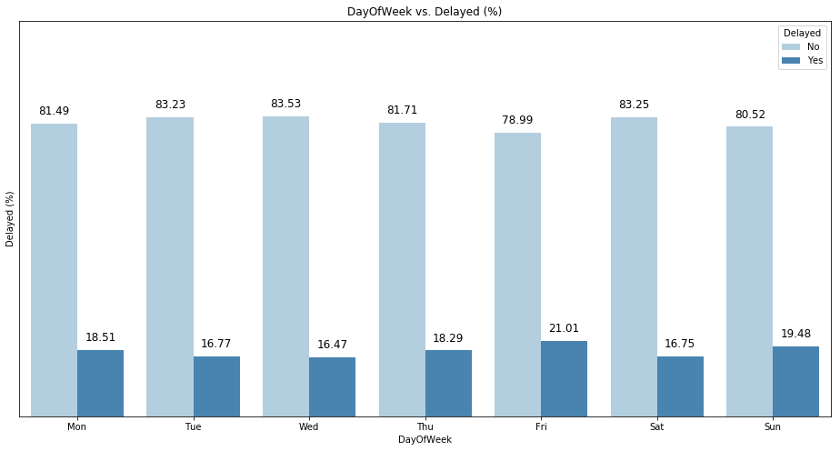

```python
#Exploring DayOfWeek and Delays relationship:
bar_by_column('DayOfWeek', 'Delayed')
days = ['Mon', 'Tue', 'Wed', 'Thu', 'Fri', 'Sat', 'Sun']
plt.xticks(range(len(days)), days);
```

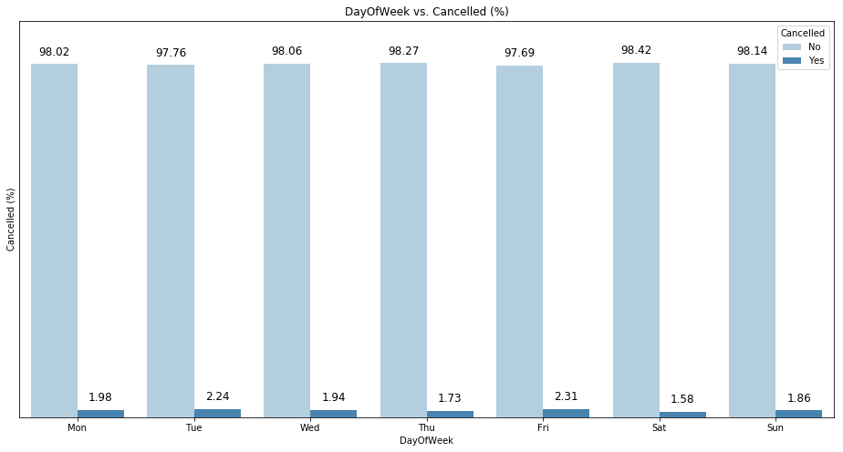

```python
#Exploring DayOfWeek and Delays relationship:
bar_by_column('DayOfWeek', 'Cancelled')
days = ['Mon', 'Tue', 'Wed', 'Thu', 'Fri', 'Sat', 'Sun']
plt.xticks(range(len(days)), days);
```

Fridays also has the highest rate for cancellation, however, in comparison to delay rates is very minimal at 2.3 percent.

> checking if diverted flights get more delays:

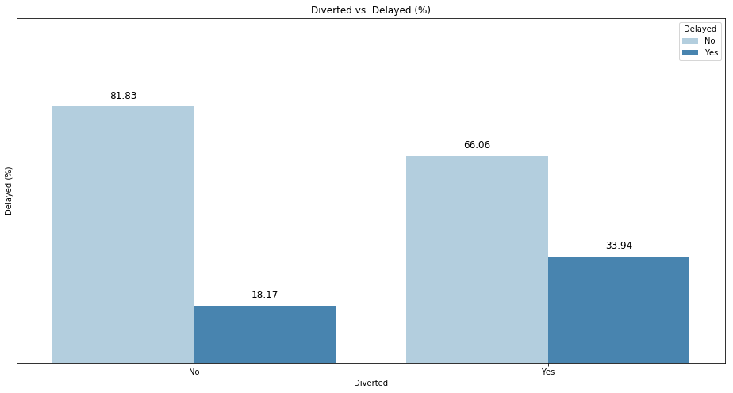

```python
# lets see the diverted and delayed relationship:
bar_by_column('Diverted', 'Delayed')
ticks = ['No', 'Yes']
plt.xticks(range(len(ticks)), ticks);
```

I was expecting this result, diverted flights have a higher percentage of delays. No surprises here.

```python
#value count for unique carriers:
print(df_clean['UniqueCarrier'].value_counts())
```

```
WN    1201754
AA     604885
OO     567159
MQ     490693
US     453589
DL     451931
UA     449515
XE     374510
NW     347652
CO     298455
EV     280575
9E     262208
FL     261684
YV     254930
OH     197607
B6     196091
AS     151102
F9      95762
HA      61826
AQ       7800
Name: UniqueCarrier, dtype: int64
```

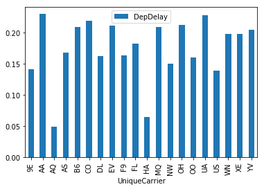

```python
#UniquerCarrier and DepDelay:
df_clean.groupby(['UniqueCarrier']).agg({'DepDelay':lambda x: (x>=15).sum()/len(x)}).plot.bar()
plt.show()
```

```python
# converting value counts to percentages, so we can see both delay yes/no and carriers in a plot:
def bar_by_column(col, against):
    flights_counts = (df_clean.groupby([col])[against]
                         .value_counts(normalize=True)
                         .rename(against+' (%)')
                         .mul(100)
                         .reset_index()
                         .sort_values(against+' (%)', ascending=False))

    plt.figure(figsize=[16,8])
    plt.yticks([])
    plt.title(col + ' vs. ' + against+' (%)')


    g = sb.barplot(x=col, y=against+' (%)', hue=against, data=flights_counts, palette='Blues')

    # write percentages above bars
    for p in g.patches:
        g.annotate("%.2f" % p.get_height(), (p.get_x() + p.get_width() / 2., p.get_height()),
                   ha='center', fontsize=12, xytext=(0, 10), textcoords='offset points', )

    # change legend
    leg = g.axes.get_legend()
    labels = ['No', 'Yes']
    for t, l in zip(leg.texts, labels): t.set_text(l)

    # To make space for the annotations
    _ = g.set_ylim(0, 110)
```

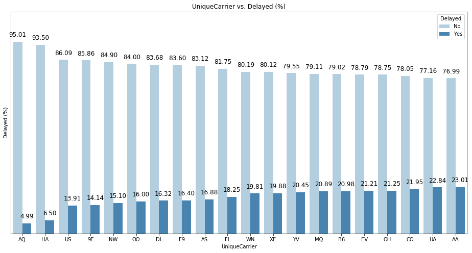

```python
bar_by_column('UniqueCarrier', 'Delayed')
```

As you go to the right the percentages of delays goes up. data is normalized all across.

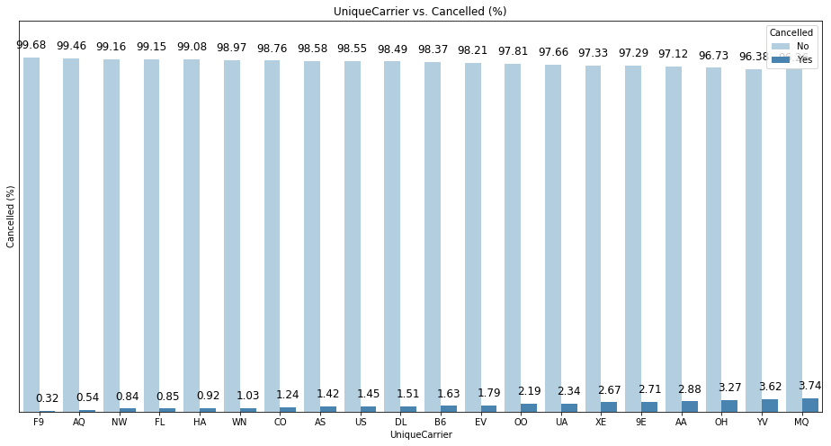

```python
bar_by_column('UniqueCarrier', 'Cancelled')
```

The effect of Carriers on flight cancellation is minimal in comparison to delays. Minimum cancallation is for F9 @ .3% and the max cancellation is for MQ @3.7%.

Next I'd like to explore any possible relationship between Origin/Delay and Origin/Cancellation:

```python
#value count for Origins:
print(df_clean['Origin'].value_counts())
```

```
ATL    414513
ORD    350380
DFW    281281
DEN    241443
LAX    215608
PHX    199408
IAH    185172
LAS    172876
DTW    161989
SFO    140587
SLC    139088
EWR    138506
MCO    130872
MSP    130289
CLT    126045
LGA    119135
JFK    118804
BOS    117915
SEA    109069
BWI    104074
PHL    100499
SAN     93775
CVG     91265
MDW     87619
DCA     86662
MEM     80966
TPA     78179
IAD     76031
FLL     67177
CLE     65795
        ...
OTH       515
LMT       511
SLE       486
ACK       457
STX       436
MKG       396
YKM       340
ALO       323
CMX       318
RFD       290
BPT       276
PLN       264
WYS       264
RHI       221
TEX       194
LWB       185
HTS       158
ITH       132
SUX       122
BLI       120
AKN       116
ACY       116
DLG       116
ADK       102
GST        85
BJI        74
INL        72
TUP        10
PIR         5
PUB         2
Name: Origin, Length: 303, dtype: int64
```

```python
# Get percentages of delays by origing using the following function:
def get_percentages(data, col, against):
    flights_totals = (data.groupby([col])[against]
                         .value_counts(normalize=True)
                         .rename(against+' (%)')
                         .mul(100)
                         .reset_index()
                         .sort_values(against+' (%)', ascending=False))

    return flights_totals.query(against+' == 1 ')[[col, against+' (%)']]

delayed_flights_by_origin = get_percentages(df_clean, 'Origin', 'Delayed')
delayed_flights_by_origin.head(10)
```

|  | Origin | Delayed (%) |
| --- | --- | --- |
| 465 | PUB | 50.000000 |
| 25 | AKN | 46.551724 |
| 167 | DLG | 45.689655 |
| 17 | ADK | 36.274510 |
| 109 | CEC | 34.242709 |
| 85 | BRW | 34.065934 |
| 9 | ACK | 33.698031 |
| 425 | OTH | 30.679612 |
| 195 | EYW | 27.552032 |
| 555 | STX | 27.522936 |

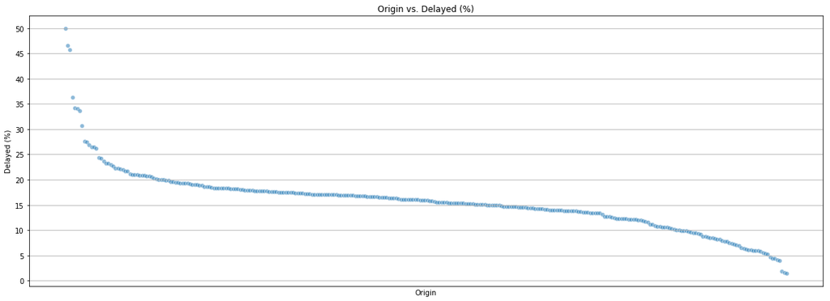

```python
def scatter_by_column(data, col, against):
    plt.figure(figsize=[20,7])
    sb.scatterplot(data=data, x=col, y=against+' (%)', alpha=.5)
    plt.yticks(np.arange(0,data[against+' (%)'].max()+5,5))
    plt.grid()
    plt.title(col + ' vs. ' + against+' (%)')
    plt.xticks([]);

scatter_by_column(delayed_flights_by_origin, 'Origin', 'Delayed')
```

```python
print(df_clean.groupby('Origin').size().describe())
print(df_clean.groupby('Origin').size().sort_values().head(20))
```

```
count       303.000000
mean      23134.415842
std       50462.325797
min           2.000000
25%        1324.000000
50%        4262.000000
75%       16329.500000
max      414513.000000
dtype: float64
Origin
PUB      2
PIR      5
TUP     10
INL     72
BJI     74
GST     85
ADK    102
DLG    116
ACY    116
AKN    116
BLI    120
SUX    122
ITH    132
HTS    158
LWB    185
TEX    194
RHI    221
WYS    264
PLN    264
BPT    276
dtype: int64
```

There are 303 different origins in our dataset. However, some of these origins have very minimal flight numbers. I am going to select the first quartile as my threshold to keep the data for a better and more accurate visualization of the data:

```python
#here making the first quartile (25% @1324.00) as the threshold
#The mask method is an application of the if-then idiom
data = df_clean.groupby('Origin').size()
mask = data.apply(lambda x: x >= 1324)
origins = data[np.where(mask)[0]].index
```

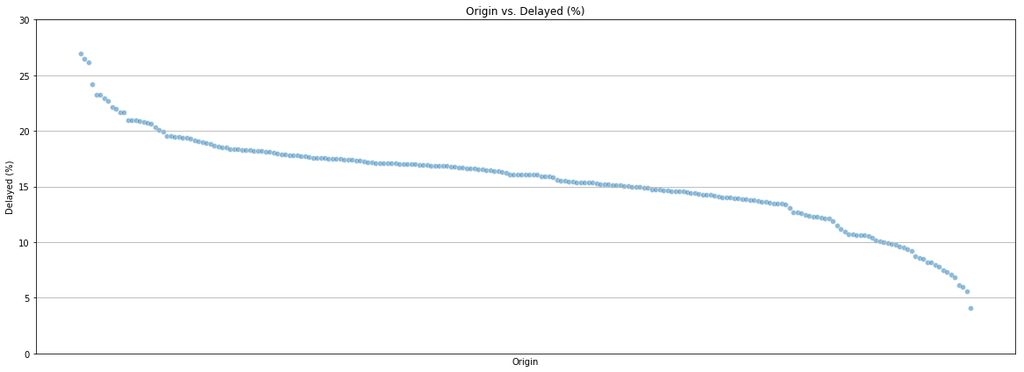

```python
data = df_clean[df_clean['Origin'].isin(origins)]
delayed_flights_by_origin = get_percentages(data, 'Origin', 'Delayed')

scatter_by_column(delayed_flights_by_origin, 'Origin', 'Delayed')
```

```python
# lets look at the Delayed data summary now:
delayed_flights_by_origin['Delayed (%)'].describe()
```

```
count    227.000000
mean      15.580670
std        3.854774
min        4.098855
25%       13.814914
50%       16.067802
75%       17.715212
max       26.914358
Name: Delayed (%), dtype: float64
```

We see that the origin does have an impact on flight delays. We can see from the above that most origins have delays that fall between 13 to 17%, but there are some origins that have very hight or very low rates.

> next, I want to understand the relationship between the origin and cancellation:

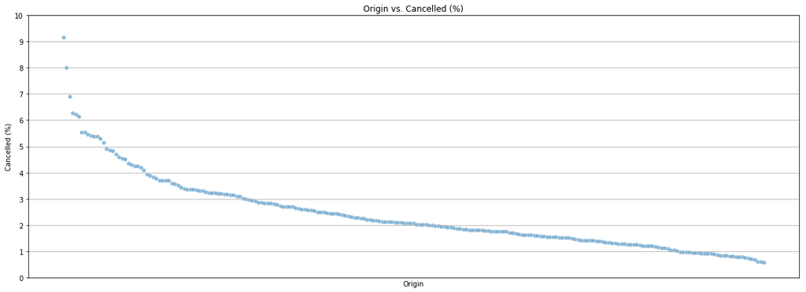

```python
#using the same dataset that excluded low number of flights from the origins with less counts:

cancelled_flights_by_origin = get_counts_percentages(data, 'Origin', 'Cancelled')

scatter_by_column(cancelled_flights_by_origin, 'Origin', 'Cancelled')
plt.yticks(np.arange(0,cancelled_flights_by_origin['Cancelled (%)'].max()+1,1));
```

```python
#description for the cancelled data:
cancelled_flights_by_origin['Cancelled (%)'].describe()
```

```
count    227.000000
mean       2.397926
std        1.404443
min        0.574351
25%        1.410436
50%        2.064837
75%        3.099045
max        9.157716
Name: Cancelled (%), dtype: float64
```

We can see from the above that origin affect the cancelling flights as well, but not as strong as their effect on the delays. On average most origins have cancellation rate of ~2.5. Since this is not a major effect, we might want to eliminate this for our final conclusion section.

> Next, will explore the destination and delay/cancellation relationship:

```python
df_clean.groupby('Dest').size().describe()
```

```
count       304.000000
mean      23058.315789
std       50401.780012
min           2.000000
25%        1309.000000
50%        4251.500000
75%       16261.500000
max      414521.000000
dtype: float64
```

```python
#using the 1st quartile as the threshold again:

data = df_clean.groupby('Dest').size()
mask = data.apply(lambda x: x >= 1309)
destinations = data[np.where(mask)[0]].index
```

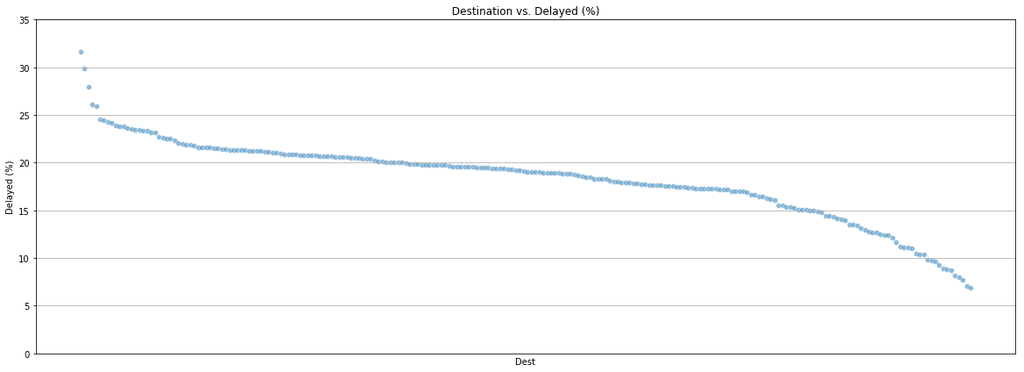

```python
data = df_clean[df_clean['Dest'].isin(destinations)]
delayed_flights_by_dest = get_percentages(data, 'Dest', 'Delayed')

scatter_by_column(delayed_flights_by_dest, 'Dest', 'Delayed')
plt.xlabel('Dest');
plt.title('Destination vs. Delayed (%)')
```

```python
# describing %of delayed based on destination:
delayed_flights_by_dest['Delayed (%)'].describe()
```

```
count    228.000000
mean      18.334433
std        4.067484
min        6.839772
25%       16.857617
50%       19.091382
75%       20.762110
max       31.581836
Name: Delayed (%), dtype: float64
```

Destination has an impact on the delays, just like the origins.

> next, lets look at destination and cancellation to see if get the same trend as the origin and cancellation:

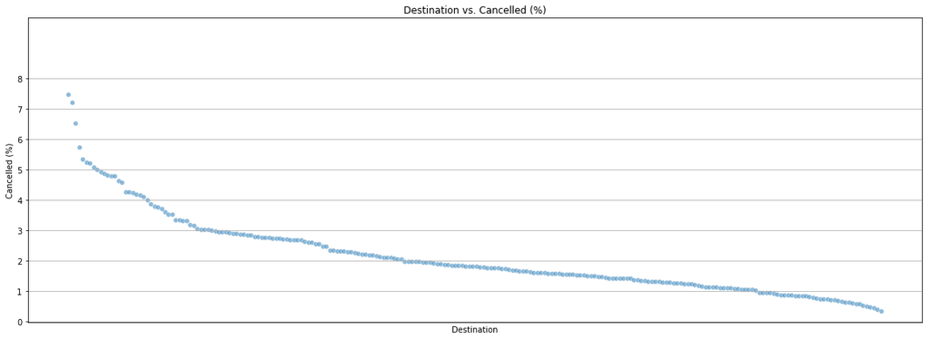

```python
cancelled_flights_by_dest = get_counts_percentages(data, 'Dest', 'Cancelled')

scatter_by_column(cancelled_flights_by_dest, 'Dest', 'Cancelled')
plt.yticks(np.arange(0,cancelled_flights_by_dest['Cancelled (%)'].max()+1,1));
plt.xlabel('Destination')
plt.title('Destination vs. Cancelled (%)');
```

```python
cancelled_flights_by_dest['Cancelled (%)'].describe()
```

```
count    228.000000
mean       2.139699
std        1.273947
min        0.346157
25%        1.269406
50%        1.816438
75%        2.762238
max        7.476636
Name: Cancelled (%), dtype: float64
```

Destinations have a very similar affect on cancellation as the origin with median of 1.8%. As such, like the origin/cancellation relationship we can leave these findings here at the exploration fase.

### Talk about some of the relationships you observed in this part of the investigation. How did the feature(s) of interest vary with other features in the dataset?

> I observed that many of the categorical features/variables (e.g. UniqueCarrier, Origin, Dest, DayOfWeek and Diverted) have relationships with my variables of interested ( Delayed and Cancelled)

### Did you observe any interesting relationships between the other features (not the main feature(s) of interest)?

> yes, observation of expected relationships were found. For example departure delay will have an impact on the arrival delay as one may be caused by the other. There seem a big correlation between the three variables of AirTime, ElapsedTime, and Distance. All these depend on each other with minor defrences.

## Multivariate Exploration

> Create plots of three or more variables to investigate your data even further. Make sure that your investigations are justified, and follow from your work in the previous sections.

```python
sample = df_clean.sample(1000000)
```

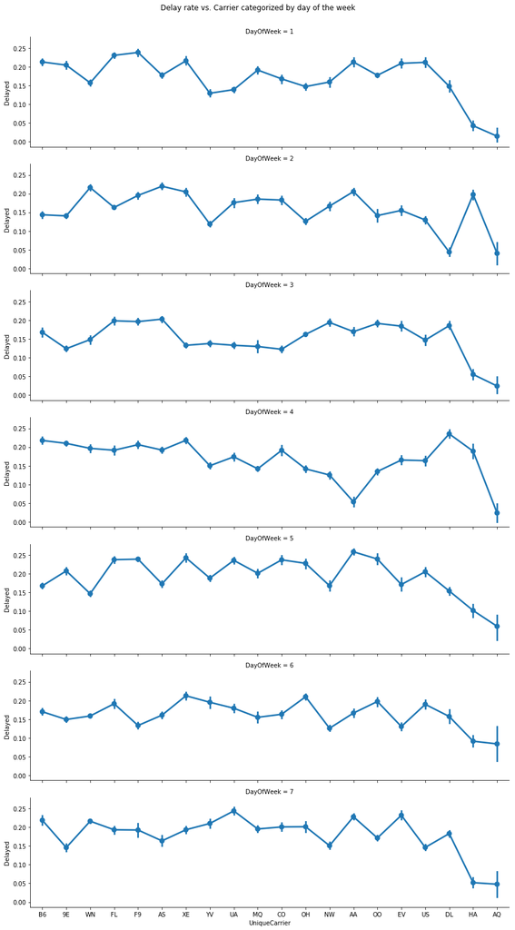

```python
###### show days of the week in order
##question here is how to show the actual days of the week instead of the numbers resembed in the data. Do I need to re-name in the data or can this be done at this level*** ask mentor.

# Delayed, DayOfWeek, UniqueCarrier
g = sb.FacetGrid(data=sample, col='DayOfWeek', col_wrap=1, aspect=4)
g.map(sb.pointplot, 'UniqueCarrier', 'Delayed')
g.fig.suptitle('Delay rate vs. Carrier categorized by day of the week', y=1.02);
```

> AQ has the lowest number of delay rates overall regardless of the day of the week.

> FL generally has high numbers of delay.

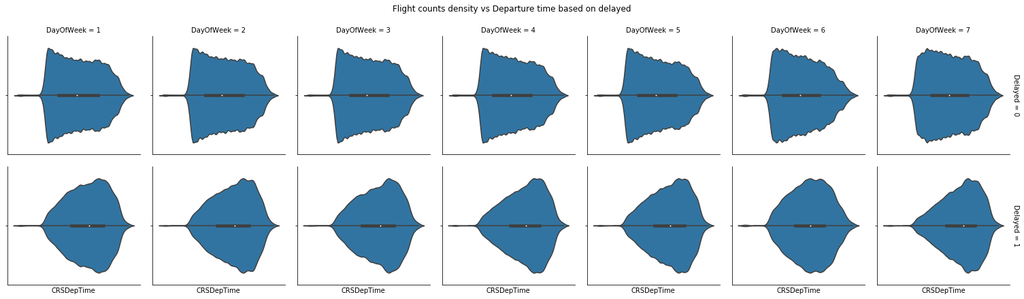

```python
# Delayed, DayOfWeek, DepTime
samp.CRSDepTime = samp.CRSDepTime.astype('timedelta64[s]').sort_values()
g = sb.FacetGrid(data=samp, col='DayOfWeek', row='Delayed', margin_titles=True)
g.map(sb.violinplot, 'CRSDepTime');
g.set(xticks=[])
g.fig.suptitle('Flight counts density vs Departure time based on delayed', y=1.05);
```

It seems from the violet plot above and the historgram below, day of the week does not have an impact on the delay rate based on the schedule departuer time. On all days, high delays are skewed to the right and low delays are skewed to the left. This means that late departure times have higher delay rates and early departure times have lower delay rates or as the day progresses, more delays are expected.

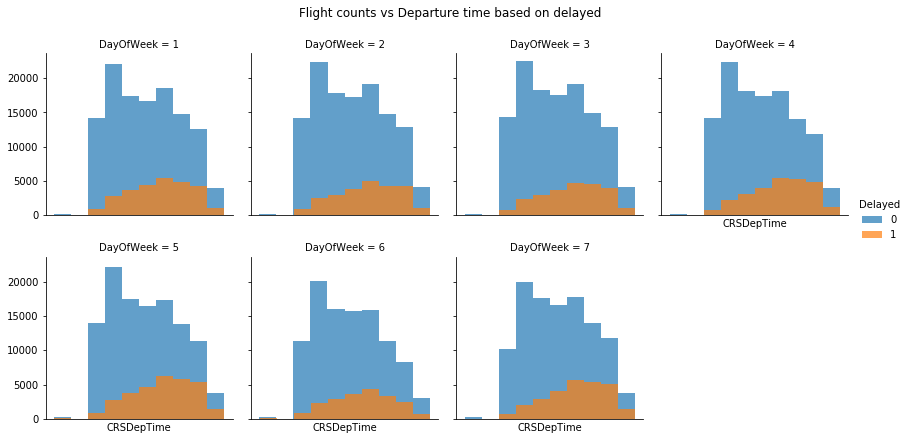

```python
g = sb.FacetGrid(data=samp, col='DayOfWeek', hue='Delayed', height=3, col_wrap=4)
g = (g.map(plt.hist, 'CRSDepTime', alpha=.7).add_legend())
g.set(xticks=[]);
g.fig.suptitle('Flight counts vs Departure time based on delayed', y=1.05);
```

### Talk about some of the relationships you observed in this part of the investigation. Were there features that strengthened each other in terms of looking at your feature(s) of interest?

Other than that the way that departure times were affecting flights delay rate didn't change when categorized them by the day of the week. Which supports what we observed before about the strong relationship between departure times and flights delay rates.

### Were there any interesting or surprising interactions between features?

> How days of the week had an impact on the operation of most carriers.

> At the end of your report, make sure that you export the notebook as an html file from the `File > Download as... > HTML` menu. Make sure you keep track of where the exported file goes, so you can put it in the same folder as this notebook for project submission. Also, make sure you remove all of the quote-formatted guide notes like this one before you finish your report!

> If there were no time constrains, I would perhaps bring in more years of data to run a multiple year comparison and find trends over the years.